# Analiza skupień

## **Dane**

### Podgląd danych:

|  | zawartosc.alk | cena | dostepnosc | znajomosc | preferencje |
| --- | --- | --- | --- | --- | --- |
| Zywiec | 5.6 | 2.90 | 1.90 | 1.95 | 2.65 |
| Desperados | 6.0 | 4.15 | 1.85 | 1.77 | 0.89 |
| Kasztelan | 5.7 | 2.47 | 1.80 | 1.84 | 2.17 |
| Wojak | 5.0 | 2.10 | 0.45 | 1.41 | 0.38 |
| Tyskie | 5.6 | 2.53 | 1.90 | 1.93 | 1.48 |
| Heineken | 5.0 | 3.64 | 1.60 | 1.90 | 1.14 |
| Warka | 5.7 | 2.59 | 1.20 | 1.92 | 1.06 |
| Łomża | 6.0 | 2.60 | 1.10 | 1.66 | 0.80 |
| Lech | 5.2 | 2.82 | 1.80 | 1.90 | 1.04 |
| Perła | 6.0 | 2.56 | 1.55 | 1.79 | 1.65 |
| Specjal | 6.0 | 2.36 | 0.10 | 0.84 | 0.43 |
| Żubr | 6.0 | 2.49 | 1.50 | 1.84 | 0.83 |
| Redds | 4.5 | 3.87 | 1.40 | 1.69 | 0.98 |
| Carlsberg | 6.0 | 3.17 | 1.85 | 1.87 | 0.82 |
| Somersby | 4.5 | 4.04 | 1.30 | 1.59 | 1.00 |
| Tatra_Pils | 6.0 | 2.00 | 1.45 | 1.30 | 0.55 |
| Harnas | 6.0 | 1.99 | 1.65 | 1.66 | 1.02 |
| Tatra_mocne | 7.0 | 2.62 | 1.10 | 1.44 | 0.35 |
| Okocim_mocne | 7.1 | 2.71 | 1.30 | 1.77 | 0.76 |
| Debowe_mocne | 7.0 | 2.89 | 1.15 | 1.44 | 0.34 |

### Wstępna analiza danych

#### Podstawowe statystyki:

|  | zawartosc.alk | cena | dostepnosc | znajomosc | preferencje |
| --- | --- | --- | --- | --- | --- |
|  | Min. :4.500 | Min. :1.990 | Min. :0.100 | Min. :0.840 | Min. :0.3400 |
|  | 1st Qu.:5.500 | 1st Qu.:2.485 | 1st Qu.:1.188 | 1st Qu.:1.552 | 1st Qu.:0.7075 |
|  | Median :6.000 | Median :2.610 | Median :1.475 | Median :1.770 | Median :0.9350 |
|  | Mean :5.795 | Mean :2.825 | Mean :1.397 | Mean :1.675 | Mean :1.0170 |
|  | 3rd Qu.:6.000 | 3rd Qu.:2.967 | 3rd Qu.:1.800 | 3rd Qu.:1.877 | 3rd Qu.:1.0800 |
|  | Max. :7.100 | Max. :4.150 | Max. :1.900 | Max. :1.950 | Max. :2.6500 |

#### Macierz korelacji:

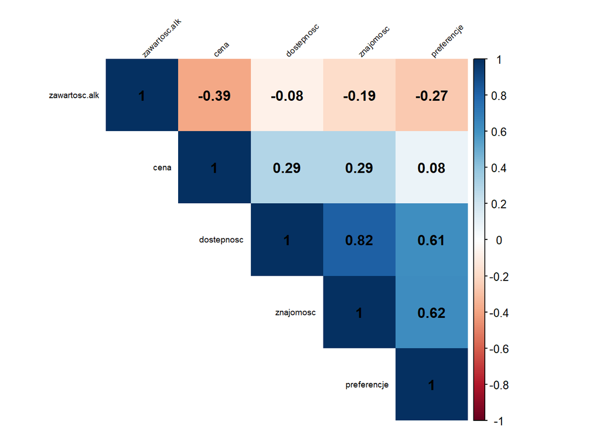

#### Współczynniki zmienności:

|  | zawartosc.alk | cena | dostepnosc | znajomosc | preferencje |
| --- | --- | --- | --- | --- | --- |
| Współczynnik zmienności | 12.52 | 22.67 | 33.87 | 16.5 | 58.41 |

## **Grupowanie podziałowe**

#### **Metoda k-średnich**

Funkcja `kmeans()` z biblioteki `stats`:

`kmeans(x, centers, nstart, ...)`

gdzie:

- x - dane
- centers - liczba grup, na jaką chce się podzielić obiekty
- nstart - liczba określająca ile razy wykonany zostanie podział

Dokumentacja: https://www.rdocumentation.org/packages/stats/versions/3.6.2/topics/kmeans

**Funkcje przydatne do dalszej analizy wyników:**

- funkcja `describeBy()` z biblioteki `psych` - można wykorzystać do porównania statystyk w grupach
- funkcja `fviz_cluster()` z biblioteki `factoextra` - można wykorzystać do wizualizacji wyników (uwzględnia wszystkie rozważane zmienne)

Jak wybrać optymalną liczbę grup?

- **Metoda łokcia (elbow method)** - liczba grup dobierana jest tak, aby zminimalizować zmienność wewnątrz wszystkich klastrów.
- **Metoda profilu (Silhouette method)** - liczba grup dobierana jest poprzez uwzględnienie dystantsu pomiędzy grupami oraz dystansu pomiędzy obiektami w grupie.

  Dla każdego obiektu obliczany jest współczynnik, na podstawie którego można ocenić, czy obiekt ten został przypisany do odpowiedniej grupy. Interpretacja wartości tego współczynnika:
  - bliskie -1: obiekt lepiej pasuje do innej grupy
  - bliskie 0: obiekt jest na graniczy dwóch grup
  - bliskie 1: obiekt jest bardzo dobrze dopasowany

  Dany podział na grupy oceniany jest na podstawie uśrednionych wartości współczynników dla każdego z obiektów.

Obie powyższe metody można zastosować korzystając z funkcji `fviz_nbclust()` z biblioteki `factoextra`.

#### **Metoda k-medoid**

Funkcja `pam()` z biblioteki `cluster`:

`pam(x, k, ...)`

gdzie:

- x - dane
- k - liczba grup, na jaką chce się podzielić obiekty

Dokumentacja: https://www.rdocumentation.org/packages/cluster/versions/2.1.2/topics/pam

**Funkcje przydatne do dalszej analizy wyników:**

- funkcja `describeBy()` z biblioteki `psych` - można wykorzystać do porównania statystyk w grupach
- funkcja `fviz_cluster()` z biblioteki `factoextra` - można wykorzystać do wizualizacji wyników (uwzględnia wszystkie rozważane zmienne)

Jak wybrać optymalną liczbę grup?

- **Metoda łokcia (elbow method)** - liczba grup dobierana jest tak, aby zminimalizować zmienność wewnątrz wszystkich klastrów.
- **Metoda profilu (Silhouette method)** - liczba grup dobierana jest poprzez uwzględnienie dystantsu pomiędzy grupami oraz dystansu pomiędzy obiektami w grupie.

  Dla każdego obiektu obliczany jest współczynnik, na podstawie którego można ocenić, czy obiekt ten został przypisany do odpowiedniej grupy. Interpretacja wartości tego współczynnika:
  - bliskie -1: obiekt lepiej pasuje do innej grupy
  - bliskie 0: obiekt jest na graniczy dwóch grup
  - bliskie 1: obiekt jest bardzo dobrze dopasowany

  Dany podział na grupy oceniany jest na podstawie uśrednionych wartości współczynników dla każdego z obiektów.

Obie powyższe metody można zastosować korzystając z funkcji `fviz_nbclust()` z biblioteki `factoextra`.

## **Grupowanie hierarchiczne**

#### **Kolejne kroki:**

1. **Wyznaczenie macierzy odległości pomiędzy obiektami**

   Funkcja `dist()` z biblioteki `stats`:

   `dist(x, method, ...)`

   gdzie:
   - x - dane
   - method - metoda (np. “euclidean”, “manhattan”, “minkowski”, “maximum”)
2. **Wykonanie grupowania hierarchicznego za pomocą wybranej metody**

   Funkcja `hclust()` z biblioteki `stats`:

   `hclust(d, method, ...)`

   gdzie:
   - d - macierz odległości pomiędzy obiektami
   - method - metoda (np. “ward.D”, “ward.D2”, “single”, “complete”, “average”, “median”, “centroid”)
3. **Analiza wyników (wybór liczby grup)**

   Wybór liczby grup:
   - analiza dendrogramu,
   - analiza wykresu odległości wiązania względem etapów wiązania,
   - analiza indeksów ocen jakości klasyfikacji.

   Przykładowe indeksy ocen jakości klasyfikacji:
   - index Calińskiego i Harabasza (funkcja `index.G1()` z biblioteki `clusterSim`),
   - index Bakera i Huberta (funkcja `index.G2()` z biblioteki `clusterSim`),
   - index Huberta i Levine’a (funkcja `index.G3()` z biblioteki `clusterSim`),
   - index Silhouette (funkcja `index.S()` z biblioteki `clusterSim`).

   Dodatkowe elementy:
   - Funkcja `cutree()` z biblioteki `stats` - funkcja służąca do przycinania dendrogramu (podziału obserwacji na grupy).
   - Modyfikacje dendrogramów (zmiana kształtu, dodawanie kolorów, podział na grupy): http://www.sthda.com/english/wiki/beautiful-dendrogram-visualizations-in-r-5-must-known-methods-unsupervised-machine-learning